# Relatório Informativo sobre Dengue

Vigilância Epidemiológica do Estado de Rosas (Curso Abrasco)

2025-03-25

## Introdução

1. O que é dengue

A dengue é a arbovirose urbana mais prevalente nas Américas, principalmente no Brasil. É uma doença febril que tem se mostrado de grande importância em saúde pública nos últimos anos. O vírus dengue (DENV) é um arbovírus transmitido pela picada da fêmea do mosquito *Aedes aegypti* e possui quatro sorotipos diferentes (DENV-1, DENV-2, DENV-3 e DENV-4).

1. Principais Sintomas
- Febre alta > 38°C.
- Dor no corpo e articulações
- Dor atrás dos olhos.
- Mal estar.
- Falta de apetite.
- Dor de cabeça.
- Manchas vermelhas no corpo.
2. Transmissão

O vírus da dengue (DENV) pode ser transmitido ao homem principalmente por via vetorial, pela picada de fêmeas de *Aedes aegypti* infectadas, no ciclo urbano humano–vetor–humano. Os relatos de transmissão por via vertical (de mãe para filho durante a gestação) e transfusional são raros.

3. Diagnóstico
- Métodos diretos
  - Pesquisa de vírus (isolamento viral por inoculação em células);
  - Pesquisa de genoma do vírus da dengue por transcrição reversa seguida de reação em cadeia da polimerase (RT-PCR);
- Métodos indiretos
  - Pesquisa de anticorpos IgM por testes sorológicos (ensaio imunoenzimático – ELISA)
  - Teste de neutralização por redução de placas (PRNT);
  - Inibição da hemaglutinação (IH);
  - Pesquisa de antígeno NS1 (ensaio imunoenzimático – ELISA);
  - Patologia: estudo anatomopatológico seguido de pesquisa de antígenos virais por imuno-histoquímica (IHQ).

## Análises

### 1. Distribuição de casos por semana epidemiológica

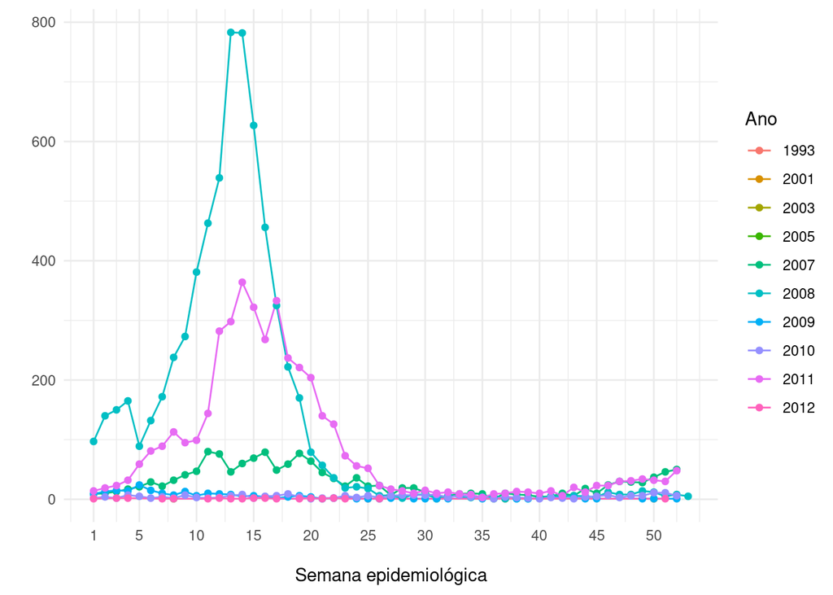

### 2. Distribuição de casos por classificação final

| Ano | Cura | Óbito | Outro | Ignorado |
| --- | --- | --- | --- | --- |
| 1993 | 0 | 0 | 1 | 0 |
| 2001 | 0 | 0 | 1 | 0 |
| 2003 | 1 | 0 | 0 | 0 |
| 2005 | 1 | 0 | 0 | 0 |
| 2007 | 347 | 27 | 1074 | 50 |
| 2008 | 1164 | 453 | 4751 | 219 |
| 2009 | 29 | 7 | 166 | 8 |
| 2010 | 86 | 30 | 105 | 13 |
| 2011 | 3584 | 52 | 541 | 45 |
| 2012 | 18 | 1 | 2 | 5 |